# Introduction à la modélisation statistique bayésienne

Ladislas Nalborczyk & Thierry Phénix

### Planning

Cours 1: Introduction à l'inférence bayésienne

Cours 2: Modèle beta-binomial

Cours 3 & 4: Modèle de régression linéaire

Cours 5: Markov Chain Monte Carlo

Cours 6: Modèle linéaire généralisé

Cours 7: Comparaison de modèles

Cours 8: Modèles multi-niveaux

Cours 9: Introduction à `brms`

**Cours 10: Data Hackaton**

### Introduction

Cinq problèmes, cinq jeux de données. Le but est de comprendre et d'analyser ces données pour répondre à une (ou plusieurs) question(s) théorique(s).

Vous devrez écrire le modèle mathématique, puis fitter ce modèle en utilisant `rethinking` ou `brms` (ou les deux).

Ensuite, vous devrez checker le modèle, interpréter les résultats, et écrire un paragraphe de résultats (de type article) pour décrire vos analyses et vos conclusions.

Les problèmes sont classés par ordre croissant de difficulté. Vous pouvez travailler individuellement ou par groupe, et des propositions de correction sont disponibles dans les slides à la suite des énoncés.

### Problème n°1

Peut-on prédire la taille d'un individu par la taille de ses parents ?

```r
library(tidyverse)

d1 <- read.csv("parents.csv")
head(d1, 10)
```

```
   gender height mother father
1       M   62.5     66     70
2       M   64.6     58     69
3       M   69.1     66     64
4       M   73.9     68     71
5       M   67.1     64     68
6       M   64.4     62     66
7       M   71.1     66     74
8       M   71.0     63     73
9       M   67.4     64     62
10      M   69.3     65     69
```

### Problème n°2

Les données suivantes documentent le naufrage du titanic. La colonne `pclass` indique la classe dans laquelle chaque passager voyageait (un proxy pour le statut socio-économique), tandis que la colonne `parch` indique le nombre de parents et enfants à bord.

Peut-on prédire la survie d'un passager en fonction de ces informations ?

```r
d2 <- read.csv("titanic.csv")
head(d2, 10)
```

```
   survival pclass gender age parch
1         0  upper   male  22     0
2         1  lower female  38     0
3         1  upper female  26     0
4         1  lower female  35     0
5         0  upper   male  35     0
6         0  lower   male  54     0
7         0  upper   male   2     1
8         1  upper female  27     2
9         1  upper female   4     1
10        1  lower female  58     0
```

### Problème n°3

Ce jeu de données recense des informations sur le diamètre (colonne `diam`) de 80 pommes (chaque pomme étant identifiée par la colonne `id`), poussant sur 10 arbres différents (colonne `tree`). On a mesuré ce diamètre pendant 6 semaines successives (colonne `time`).

```r
d3 <- read.csv("apples.csv")
head(d3, 10)
```

```
   tree apple id time diam
1     1     1  1    1 2.90
2     1     1  1    2 2.90
3     1     1  1    3 2.90
4     1     1  1    4 2.93
5     1     1  1    5 2.94
6     1     1  1    6 2.94
7     1     4  4    1 2.86
8     1     4  4    2 2.90
9     1     4  4    3 2.93
10    1     4  4    4 2.96
```

### Problème n°4

Ces données recensent le nombre de candidatures pour 6 départements (colonne `dept`) à Berkeley (données disponibles dans le package `rethinking`). La colonne `admit` indique le nombre de candidatures acceptées et la colonne `reject` le nombre de candidatures rejetées (la colonne `applications` est simplement la somme des deux), en fonction du genre des candidats (`applicant.gender`).

On veut savoir s'il existe un biais de genre dans l'admission des étudiants à Berkeley.

```r
library(rethinking)
d4 <- get(data(UCBadmit) )
head(d4, 10)
```

```
   dept applicant.gender admit reject applications
1     A             male   512    313          825
2     A           female    89     19          108
3     B             male   353    207          560
4     B           female    17      8           25
5     C             male   120    205          325
6     C           female   202    391          593
7     D             male   138    279          417
8     D           female   131    244          375
9     E             male    53    138          191
10    E           female    94    299          393
```

### Problème n°5

Le dilemme du tramway (*trolley problem*) est une expérience de pensée qui permet d'étudier les déterminants des jugements de moralité (i.e., qu'est-ce qui fait qu'on juge une action comme morale, ou pas ?).

Sous une forme générale, ce dilemme consiste à poser la question suivante: si une personne peut effectuer un geste qui bénéficiera à un groupe de personnes A, mais, ce faisant, nuira à une personne B (seule); est-il moral pour la personne d'effectuer ce geste ?

Voir [ce lien](https://fr.wikipedia.org/wiki/Dilemme_du_tramway) pour plus d'informations.

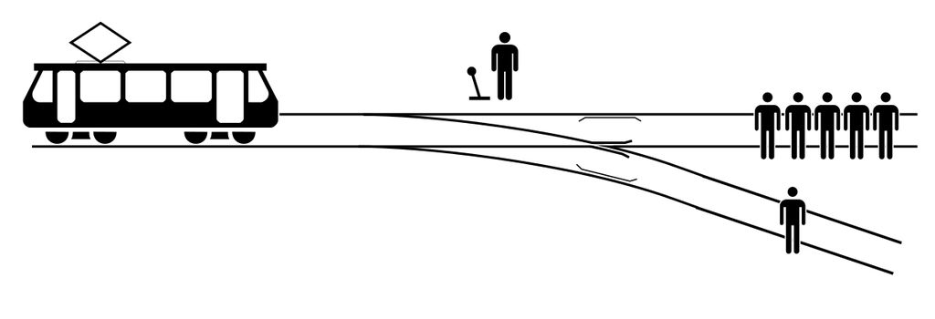

### Problème n°5

Généralement, on fait lire des scénarios aux participants de l'étude, dans lesquels un individu doit prendre une décision dans une situation similaire à celle décrite à la slide précédente. Par exemple, imaginons que Denis ait le choix entre ne rien faire et laisser un train tuer cinq personnes, ou faire dérailler ce train mais tuer une personne. Ensuite, on demande aux participants de juger de la moralité de l'action choisie de Denis, sur une échelle de 1 à 7.

Des études antérieures ont montré que ces jugements de moralité sont grandement influencés par trois mécanismes de raisonnement inconscients:

- Le **principe d'action**: un préjudice causé par une action est jugé moralement moins acceptable qu'un préjudice causé par omission
- Le **principe d'intention**: un préjudice causé come étant le moyen vers un but est jugé moralement moins acceptable qu'un préjudice étant un effet secondaire (non désiré) d'un but
- Le **principe de contact**: un préjudice causé via contact physique est jugé moralement moins acceptable qu'un préjudice causé sans contact physique

### Problème n°5

On se demande comment les jugements d'acceptabilité sont influencés par les trois principes décrits slide précédente. Ces trois principes correspondent aux trois variables, `action`, `intention`, et `contact` (dummy-coded).

```r
d5 <- read.csv("morale.csv")
head(d5)
```

```
  response     id age male action intention contact
1        4 96;434  14    0      0         0       1
2        3 96;434  14    0      0         0       1
3        4 96;434  14    0      0         0       1
4        3 96;434  14    0      0         1       1
5        3 96;434  14    0      0         1       1
6        3 96;434  14    0      0         1       1
```

### Solutions

### Solution problème n°1

La taille de la mère a l'air plus prédictive de la taille d'un individu, et ce d'autant plus si cet individu est une femme…

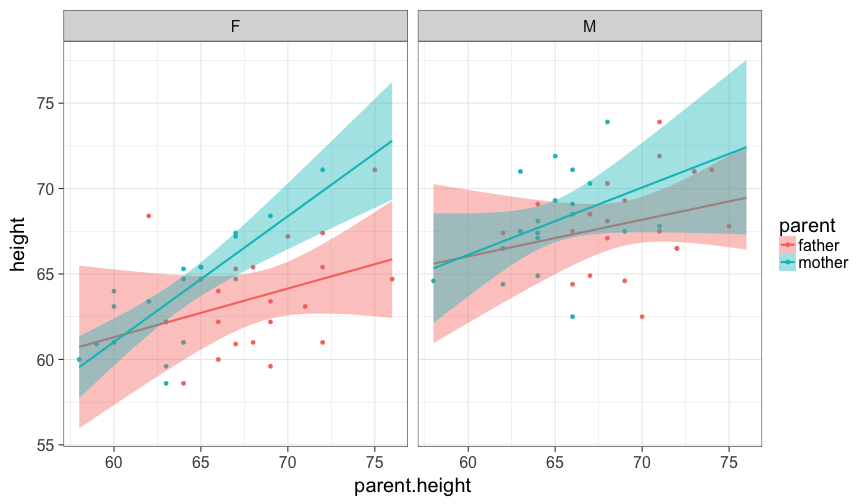

```r
d1 %>%
    gather(parent, parent.height, 3:4) %>%
    ggplot(aes(x = parent.height, y = height, colour = parent, fill = parent) ) +
    geom_point() +
    stat_smooth(method = "lm", fullrange = TRUE) +
    facet_wrap(~gender) +
    theme_bw(base_size = 20)
```

### Solution problème n°1

On peut fitter plusieurs modèles avec `rethinking` et la fonction `map`, et les comparer en utilisant le WAIC.

```r
d1$gender <- ifelse(d1$gender == "F", -0.5, 0.5)
d1$mother <- scale(d1$mother) %>% as.numeric
d1$father <- scale(d1$father) %>% as.numeric

library(rethinking)

m1 <- rethinking::map(alist(
    height ~ dnorm(mu, sigma),
    mu <- a + b1 * gender,
    a ~ dnorm(70, 10),
    b1 ~ dnorm(0, 10),
    sigma ~ dunif(0, 50) ),
    data = d1
    )

m2 <- rethinking::map(alist(
    height ~ dnorm(mu, sigma),
    mu <- a + b1 * gender + b2 * mother + b3 * father,
    a ~ dnorm(70, 10),
    c(b1, b2, b3) ~ dnorm(0, 10),
    sigma ~ dunif(0, 50) ),
    data = d1
    )
```

### Solution problème n°1

```r
m3 <- rethinking::map(alist(
    height ~ dnorm(mu, sigma),
    mu <- a + b1 * gender + b2 * mother + b3 * father + b4 * gender * mother,
    a ~ dnorm(70, 10),
    c(b1, b2, b3, b4) ~ dnorm(0, 10),
    sigma ~ dunif(0, 50) ),
    data = d1
    )

m4 <- rethinking::map(alist(
    height ~ dnorm(mu, sigma),
    mu <- a + b1 * gender + b2 * mother + b3 * father + b4 * gender * father,
    a ~ dnorm(70, 10),
    c(b1, b2, b3, b4) ~ dnorm(0, 10),
    sigma ~ dunif(0, 50) ),
    data = d1
    )
```

### Solution problème n°1

```r
compare(m1, m2, m3, m4)
```

```
    WAIC pWAIC dWAIC weight    SE   dSE
m3 189.0   7.3   0.0   0.48 12.80    NA
m2 189.2   6.6   0.2   0.43 13.05  3.38
m4 192.5   8.2   3.5   0.08 13.66  4.13
m1 206.0   3.1  17.1   0.00  9.35 11.93
```

```r
precis(m3, prob = 0.95)
```

```
       Mean StdDev  2.5% 97.5%
a     65.97   0.34 65.31 66.64
b1     3.58   0.68  2.25  4.91
b2     1.73   0.35  1.03  2.42
b3     0.59   0.34 -0.09  1.26
b4    -1.06   0.70 -2.43  0.32
sigma  2.12   0.24  1.66  2.59
```

### Solution problème n°1

On peut fitter plusieurs modèles avec `brms`, et les comparer en utilisant le WAIC.

```r
library(brms)

p1 <- c(
    prior(normal(70, 10), class = Intercept),
    prior(cauchy(0, 10), class = sigma)
    )

m1 <- brm(
    height ~ 1 + gender,
    prior = p1,
    data = d1
    )

p2 <- c(
    prior(normal(70, 10), class = Intercept),
    prior(normal(0, 10), class = b),
    prior(cauchy(0, 10), class = sigma)
    )

m2 <- brm(
    height ~ 1 + gender + mother + father,
    prior = p2,
    data = d1
    )
```

### Solution problème n°1

```r
p3 <- c(
    prior(normal(70, 10), class = Intercept),
    prior(normal(0, 10), class = b),
    prior(cauchy(0, 10), class = sigma)
    )

m3 <- brm(
    height ~ 1 + gender + mother + father + gender:mother,
    prior = p3,
    data = d1
    )

p4 <- c(
    prior(normal(70, 10), class = Intercept),
    prior(normal(0, 10), class = b),
    prior(cauchy(0, 10), class = sigma)
    )

m4 <- brm(
    height ~ 1 + gender + mother + father + gender:father,
    prior = p4,
    data = d1
    )
```

### Solution problème n°1

```r
WAIC(m1, m2, m3, m4, compare = FALSE)
```

```
     WAIC    SE
m1 205.75  8.49
m2 186.97 10.79
m3 186.65 10.22
m4 189.77 10.89
```

```r
library(broom)
tidy(m3, prob = 0.95)
```

```
             term     estimate std.error        lower        upper
1     b_Intercept   65.9753786 0.3830413   65.2138995   66.7208986
2        b_gender    3.5827300 0.7624385    2.0885606    5.0708306
3        b_mother    1.7374728 0.3918416    0.9453476    2.5337350
4        b_father    0.5837914 0.3787822   -0.1626692    1.3136298
5 b_gender:mother   -1.0364099 0.7784899   -2.5815120    0.5367335
6           sigma    2.3464717 0.2922168    1.8625172    2.9863649
7            lp__ -108.4407814 1.8689509 -112.9120867 -105.9073733
```

### Solution problème n°1

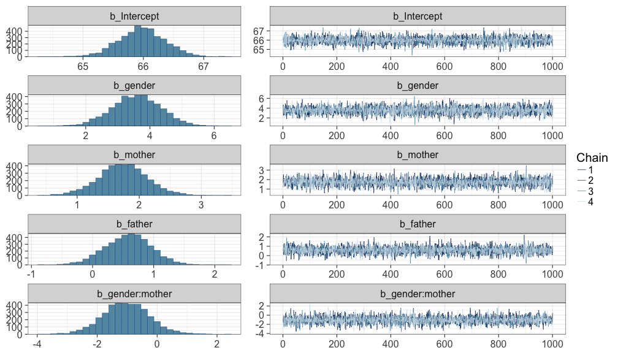

```r
m3 %>%
    plot(
        pars = "^b_",
        combo = c("hist", "trace"), widths = c(1, 1.5),
        theme = theme_bw(base_size = 20)
        )
```

### Solution problème n°1

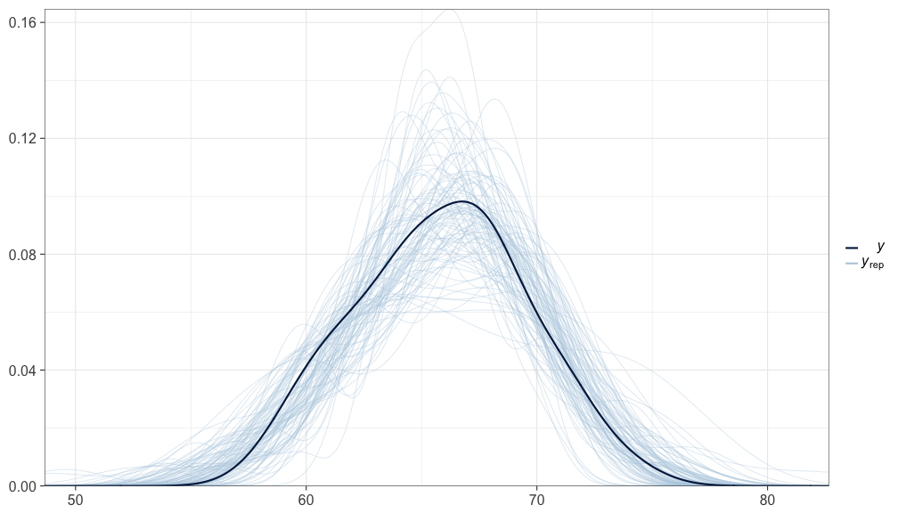

```r
pp_check(m3, nsamples = 1e2) + theme_bw(base_size = 20)
```

### Solution problème n°2

Cette situation revient à essayer de prédire un outcome dichotomique à l'aide de prédicteurs continus et / ou catégoriels. On peut utiliser un modèle de **régression logistique** (cf. cours n°6).

```r
# centering and scaling
d2 <-
    d2 %>%
    mutate(
        pclass = ifelse(pclass == "lower", -0.5, 0.5),
        gender = ifelse(gender == "female", -0.5, 0.5),
        age = scale(age) %>% as.numeric,
        parch = scale(parch) %>% as.numeric
        )
```

### Solution problème n°2

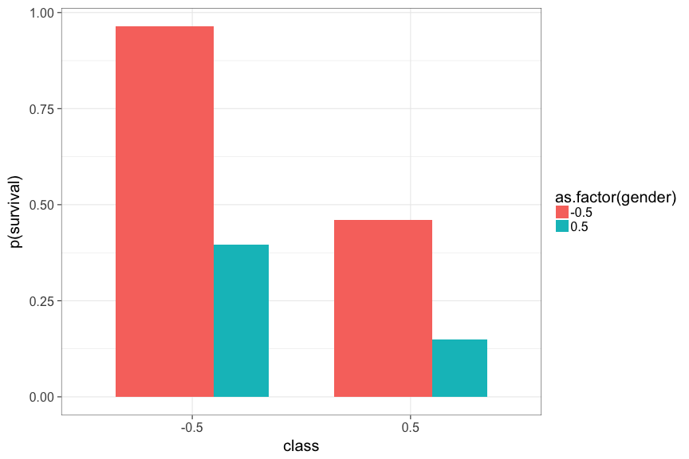

```r
d2 %>%
    group_by(pclass, gender) %>%
    summarise(p = mean(survival) ) %>%
    ggplot(aes(x = as.factor(pclass), y = p, fill = as.factor(gender) ) ) +
    geom_bar(position = position_dodge(0.5), stat = "identity") +
    theme_bw(base_size = 20) +
    xlab("class") + ylab("p(survival)")
```

### Solution problème n°2

On peut fitter plusieurs modèles avec `rethinking` et la fonction `map`, et les comparer en utilisant le `compare`

```r
# modèle sans prédicteurs
mod0 <-
    rethinking::map(
        alist(
            survival <- dbinom(1, p),
            logit(p) <- a,
            a ~ dnorm(0, 10) ),
        data = d2)
# modèles complet
mod1 <-
    rethinking::map(
        alist(
            survival <- dbinom(1, p),
            logit(p) <- a + bc*pclass + bg*gender + ba*age + bp*parch,
            a ~ dnorm(0, 10),
            c(bc, bg, ba, bp) ~ dnorm(0, 1)),
        data = d2)
```

### Solution problème n°2

```r
mod2 <-
    rethinking::map(
        alist(
            survival <- dbinom(1, p),
            logit(p) <- a + bc*pclass + bg*gender + bcg*pclass*gender,
            a ~ dnorm(0, 10),
            c(bc, bg, bcg) ~ dnorm(0, 10)),
        data = d2)

mod3 <-
    rethinking::map(
        alist(
            survival <- dbinom(1, p),
            logit(p) <- a + bc*pclass + bg*gender + bcg*pclass*gender + ba*age,
            a ~ dnorm(0, 10),
            c(bc, bg, bcg, ba) ~ dnorm(0, 10)),
        data = d2)
```

### Solution problème n°2

```r
compare(mod0, mod1, mod2, mod3)
```

```
      WAIC pWAIC dWAIC weight    SE   dSE
mod3 512.0   4.9   0.0   0.99 25.89    NA
mod1 521.0   4.6   9.1   0.01 24.21  8.11
mod2 524.0   3.8  12.1   0.00 24.97  7.83
mod0 718.1   1.0 206.1   0.00 11.06 24.58
```

```r
precis(mod3, prob = 0.95)
```

```
     Mean StdDev  2.5% 97.5%
a    0.28   0.17 -0.05  0.62
bc  -2.87   0.37 -3.59 -2.14
bg  -2.52   0.34 -3.18 -1.86
bcg  2.10   0.68  0.78  3.43
ba  -0.47   0.13 -0.73 -0.22
```

### Solution problème n°2

```r
prior0 <- prior(normal(0, 10), class = Intercept)

m0 <- brm(
    survival ~ 1,
    family = binomial(link = "logit"),
    prior = prior0,
    data = d2,
    cores = parallel::detectCores()
    )

prior1 <- c(
    prior(normal(0, 10), class = Intercept),
    prior(normal(0, 10), class = b)
    )

m1 <- brm(
    # using the dot is equivalent to say "all predictors" (all columns)
    survival ~ .,
    family = binomial(link = "logit"),
    prior = prior1,
    data = d2,
    cores = parallel::detectCores()
    )
```

### Solution problème n°2

```r
m2 <- brm(
    survival ~ 1 + pclass + gender + pclass:gender,
    family = binomial(link = "logit"),
    prior = prior1,
    data = d2,
    cores = parallel::detectCores()
    )

m3 <- brm(
    survival ~ 1 + pclass + gender + pclass:gender + age,
    family = binomial(link = "logit"),
    prior = prior1,
    data = d2,
    cores = parallel::detectCores()
    )
```

### Solution problème n°2

```r
WAIC(m0, m1, m2, m3, compare = FALSE)
```

```
     WAIC    SE
m0 717.93 11.15
m1 520.69 25.90
m2 524.62 25.41
m3 512.89 26.48
```

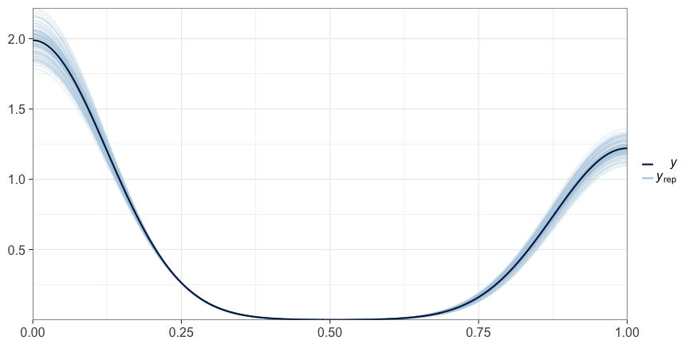

```r
pp_check(m3, nsamples = 1e2) + theme_bw(base_size = 20)
```

### Solution problème n°2

```r
summary(m3)
```

```
 Family: binomial
  Links: mu = logit
Formula: survival ~ 1 + pclass + gender + pclass:gender + age
   Data: d2 (Number of observations: 539)
Samples: 4 chains, each with iter = 2000; warmup = 1000; thin = 1;
         total post-warmup samples = 4000
    ICs: LOO = NA; WAIC = NA; R2 = NA

Population-Level Effects:
              Estimate Est.Error l-95% CI u-95% CI Eff.Sample Rhat
Intercept         0.32      0.18     0.00     0.69       1305 1.00
pclass           -2.95      0.39    -3.78    -2.24       1365 1.00
gender           -2.60      0.36    -3.39    -1.96       1652 1.00
age              -0.48      0.13    -0.75    -0.22       2893 1.00
pclass:gender     2.25      0.72     0.96     3.81       1397 1.00

Samples were drawn using sampling(NUTS). For each parameter, Eff.Sample
is a crude measure of effective sample size, and Rhat is the potential
scale reduction factor on split chains (at convergence, Rhat = 1).
```

### Solution problème n°2

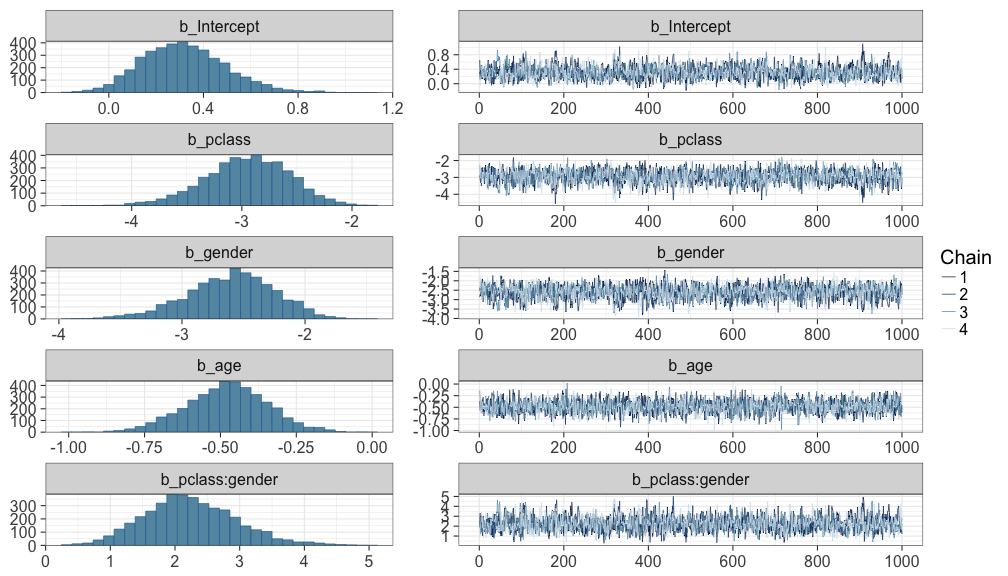

```r
m3 %>%
    plot(
        pars = "^b_",
        combo = c("hist", "trace"), widths = c(1, 1.5),
        theme = theme_bw(base_size = 20)
        )
```

### Solution problème n°3

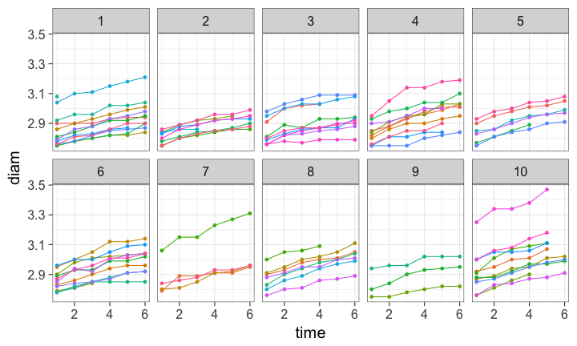

```r
d3 <- d3 %>% filter(diam != 0) # removing missing data

d3 %>% # plotting
    ggplot(aes(x = time, y = diam, colour = as.factor(apple) ) ) +
    geom_point(show.legend = FALSE) +
    geom_line(show.legend = FALSE) +
    facet_wrap(~tree, ncol = 5) +
    theme_bw(base_size = 20)
```

### Solution problème n°3

On peut fitter plusieurs modèles avec `rethinking` et la fonction `map`, et les comparer en utilisant le `compare`.

```r
# modèle avec un intercept
mod1 <- map2stan(alist(
    diam ~ dnorm(mu, sigma),
    mu <- a,
    a ~ dnorm(0, 10),
    sigma ~ dcauchy(0, 2) ),
    data = d3,
    warmup = 2000, iter = 5000,
    chains = 2, cores = parallel::detectCores()
    )
# modèle avec intercept et predicteur time
mod2 <- map2stan(alist(
    diam ~ dnorm(mu, sigma),
    mu <- a + bt*time,
    c(a, bt) ~ dnorm(0, 10),
    sigma ~ dcauchy(0, 2) ),
    data = d3,
    warmup = 2000, iter = 5000,
    chains = 2, cores = parallel::detectCores()
    )
```

### Solution problème n°3

```r
mod3 <- map2stan(alist(
    diam ~ dnorm(mu, sigma),
    mu <- a + a_tree[tree] + bt*time,
    c(a, bt) ~ dnorm(0, 10),
    a_tree[tree] ~ dcauchy(0, 10),
    sigma ~ dcauchy(0, 10) ),
    data = d3,
    warmup = 2000, iter = 5000,
    chains = 2, cores = parallel::detectCores()
    )
```

```r
mod4 <- map2stan(alist(
    diam ~ dnorm(mu, sigma),
    mu <- a_tree[tree] + bt_tree[tree]*time,
    c(a_tree, bt_tree)[tree] ~ dmvnorm2(c(a, b), sigma_tree, Rho),
    a ~ dnorm(0, 10),
    b ~ dnorm(0, 10),
    sigma_tree ~ dcauchy(0, 2),
    sigma ~ dcauchy(0, 2),
    Rho ~ dlkjcorr(2)),
    data = d3,
    warmup = 2000, iter = 5000,
    chains = 2, cores = parallel::detectCores()
    )
```

### Solution problème n°3

```r
compare(mod1, mod2, mod3, mod4)
```

```
       WAIC pWAIC dWAIC weight    SE   dSE
mod3 -823.6  13.1     0   0.62 41.96    NA
mod4 -822.6  14.0     1   0.38 43.40  3.30
mod2 -778.6   4.4    45   0.00 48.52 16.14
mod1 -701.6   3.1   122   0.00 43.55 19.92
```

### Solution problème n°3

```r
precis(mod4, depth = 2, prob = 0.95)
```

```
              Mean StdDev lower 0.95 upper 0.95 n_eff Rhat
bt_tree[1]    0.03   0.00       0.02       0.03  1194 1.00
bt_tree[2]    0.02   0.01       0.01       0.03   978 1.00
bt_tree[3]    0.02   0.00       0.02       0.03   984 1.00
bt_tree[4]    0.03   0.00       0.02       0.04   884 1.00
bt_tree[5]    0.03   0.00       0.02       0.04  1332 1.00
bt_tree[6]    0.03   0.00       0.02       0.04  1323 1.00
bt_tree[7]    0.03   0.00       0.02       0.04  1244 1.00
bt_tree[8]    0.03   0.00       0.02       0.04  1467 1.00
bt_tree[9]    0.03   0.01       0.01       0.03  1389 1.00
bt_tree[10]   0.03   0.01       0.02       0.04   605 1.00
a_tree[1]     2.82   0.02       2.78       2.85   998 1.00
a_tree[2]     2.80   0.02       2.76       2.84  1083 1.00
a_tree[3]     2.82   0.02       2.78       2.86   556 1.00
a_tree[4]     2.83   0.02       2.80       2.86  1016 1.00
a_tree[5]     2.83   0.02       2.79       2.87  1377 1.00
a_tree[6]     2.84   0.02       2.81       2.87   830 1.00
a_tree[7]     2.86   0.02       2.81       2.90   418 1.00
a_tree[8]     2.85   0.02       2.81       2.88  1114 1.00
a_tree[9]     2.81   0.02       2.76       2.86  1102 1.00
a_tree[10]    2.89   0.02       2.85       2.94   568 1.00
a             2.83   0.02       2.80       2.86   526 1.00
b             0.03   0.00       0.02       0.03   940 1.00
sigma_tree[1] 0.04   0.02       0.01       0.07  1057 1.00
sigma_tree[2] 0.00   0.00       0.00       0.01   337 1.02
sigma         0.10   0.00       0.09       0.10   621 1.00
Rho[1,1]      1.00   0.00       1.00       1.00  6000  NaN
Rho[1,2]      0.10   0.40      -0.68       0.81   883 1.00
Rho[2,1]      0.10   0.40      -0.68       0.81   883 1.00
Rho[2,2]      1.00   0.00       1.00       1.00  3666 1.00
```

### Solution problème n°3

On peut fitter plusieurs modèles avec `brms` et les comparer ensuite en utilisant le WAIC.

```r
p1 <- c(
    prior(normal(0, 10), class = Intercept),
    prior(cauchy(0, 10), class = sigma)
    )

m1 <- brm(
    diam ~ 1,
    prior = p1,
    data = d3,
    cores = parallel::detectCores()
    )

p2 <- c(
    prior(normal(0, 10), class = Intercept),
    prior(normal(0, 10), class = b),
    prior(cauchy(0, 10), class = sigma)
    )

m2 <- brm(
    diam ~ 1 + time,
    prior = p2,
    data = d3,
    cores = parallel::detectCores()
    )
```

### Solution problème n°3

```r
p3 <- c(
    prior(normal(0, 10), class = Intercept),
    prior(normal(0, 10), class = b),
    prior(cauchy(0, 10), class = sd),
    prior(cauchy(0, 10), class = sigma)
    )

m3 <- brm(
    diam ~ 1 + time + (1 | tree),
    prior = p3,
    data = d3,
    cores = parallel::detectCores()
    )

p4 <- c(
    prior(normal(0, 10), class = Intercept),
    prior(normal(0, 10), class = b),
    prior(cauchy(0, 10), class = sd),
    prior(cauchy(0, 10), class = sigma),
    prior(lkj(2), class = cor)
    )

m4 <- brm(
    diam ~ 1 + time + (1 + time | tree),
    prior = p4,
    data = d3,
    cores = parallel::detectCores(),
    control = list(adapt_delta = 0.99)
    )
```

### Solution problème n°3

```r
p5 <- c(
    prior(normal(0, 10), class = Intercept),
    prior(normal(0, 10), class = b),
    prior(cauchy(0, 10), class = sd),
    prior(cauchy(0, 10), class = sigma),
    prior(lkj(2), class = cor)
    )

m5 <- brm(
    diam ~ 1 + time + (1 + time | tree / apple),
    prior = p5,
    data = d3,
    cores = parallel::detectCores(),
    control = list(adapt_delta = 0.99)
    )
```

```r
WAIC(m1, m2, m3, m4, m5, compare = FALSE)
```

```
       WAIC    SE
m1  -701.87 43.57
m2  -778.37 48.56
m3  -824.93 43.05
m4  -822.43 43.30
m5 -2297.43 33.53
```

### Solution problème n°3

```r
summary(m5)
```

```
 Family: gaussian
  Links: mu = identity; sigma = identity
Formula: diam ~ 1 + time + (1 + time | tree/apple)
   Data: d3 (Number of observations: 451)
Samples: 4 chains, each with iter = 2000; warmup = 1000; thin = 1;
         total post-warmup samples = 4000
    ICs: LOO = NA; WAIC = NA; R2 = NA

Group-Level Effects:
~tree (Number of levels: 10)
                    Estimate Est.Error l-95% CI u-95% CI Eff.Sample Rhat
sd(Intercept)           0.02      0.01     0.00     0.05        319 1.01
sd(time)                0.00      0.00     0.00     0.01       1161 1.00
cor(Intercept,time)     0.19      0.43    -0.70     0.89        965 1.01

~tree:apple (Number of levels: 80)
                    Estimate Est.Error l-95% CI u-95% CI Eff.Sample Rhat
sd(Intercept)           0.09      0.01     0.08     0.11        899 1.00
sd(time)                0.01      0.00     0.00     0.01       1738 1.00
cor(Intercept,time)     0.50      0.13     0.23     0.72       2283 1.00

Population-Level Effects:
          Estimate Est.Error l-95% CI u-95% CI Eff.Sample Rhat
Intercept     2.83      0.01     2.81     2.86        727 1.00
time          0.03      0.00     0.03     0.03       2644 1.00

Family Specific Parameters:
      Estimate Est.Error l-95% CI u-95% CI Eff.Sample Rhat
sigma     0.02      0.00     0.01     0.02       4000 1.00

Samples were drawn using sampling(NUTS). For each parameter, Eff.Sample
is a crude measure of effective sample size, and Rhat is the potential
scale reduction factor on split chains (at convergence, Rhat = 1).
```

### Solution problème n°3

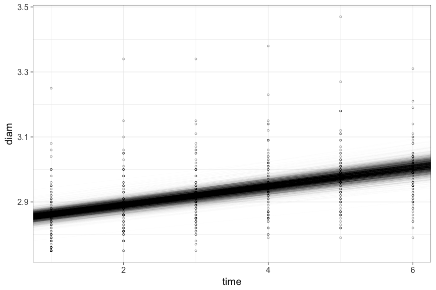

```r
post <- posterior_samples(m5, "b")

ggplot(data = d3, aes(x = time, y = diam) ) +
    geom_point(alpha = 0.5, shape = 1) +
    geom_abline(
        data = post, aes(intercept = b_Intercept, slope = b_time),
        alpha = 0.01, size = 0.5) +
    theme_bw(base_size = 20)
```

### Solution problème n°3

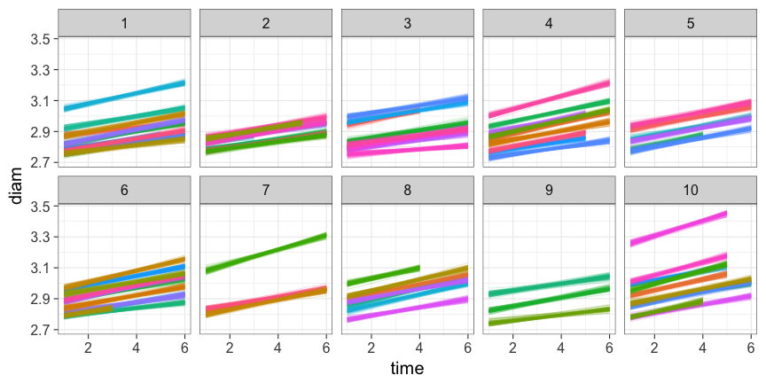

```r
library(tidybayes)
library(modelr)

d3 %>%
    group_by(tree, apple) %>%
    data_grid(time = seq_range(time, n = 1e2) ) %>%
    add_fitted_samples(m5, n = 1e2) %>%
    ggplot(aes(x = time, y = diam, colour = factor(apple) ) ) +
    geom_line(
        aes(y = estimate, group = paste(apple, .iteration) ),
        alpha = 0.2, show.legend = FALSE) +
    facet_wrap(~tree, ncol = 5) +
    theme_bw(base_size = 20)
```

### Solution problème n°4

Cette situation revient à essayer de prédire un outcome dichotomique (admit, reject) à l'aide de prédicteurs continus et / ou catégoriels.

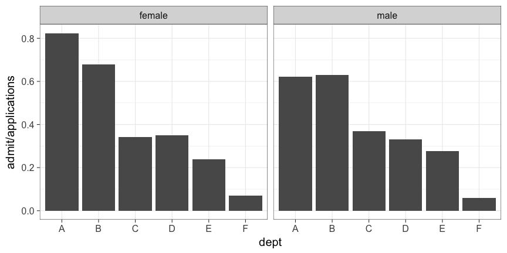

```r
d4 %>%
    ggplot(aes(x = dept, y = admit / applications) ) +
    geom_bar(stat = "identity") +
    facet_wrap(~applicant.gender) +
    theme_bw(base_size = 20)
```

### Solution problème n°4

On peut fitter plusieurs modèles avec `rethinking` et la fonction `map`, et les comparer en utilisant le WAIC.

```r
# centering gender predictor
d4$gender <- ifelse(d4$applicant.gender == "female", -0.5, 0.5)

# creating an index for department
d4$dept_id <- coerce_index(d4$dept)

# modèles avec rethinking
m1 <- map2stan(alist(
    admit ~ dbinom(applications, p),
    logit(p) <- a_dept[dept_id],
    a_dept[dept_id] ~ dnorm(a, sigma_dept),
    a ~ dnorm(0, 10),
    sigma_dept ~ dcauchy(0, 2) ),
    data = d4, warmup = 1000, iter = 5000, chains = 2)
```

### Solution problème n°4

```r
m2 <- map2stan(alist(
    admit ~ dbinom(applications, p),
    logit(p) <- a_dept[dept_id] + bm * gender,
    a_dept[dept_id] ~ dnorm(a, sigma_dept),
    a ~ dnorm(0, 10),
    bm ~ dnorm(0, 1),
    sigma_dept ~ dcauchy(0, 2) ),
    data = d4, warmup = 1000, iter = 5000, chains = 2)

m3 <- map2stan(alist(
    admit ~ dbinom(applications, p),
    logit(p) <- a_dept[dept_id] + bm_dept[dept_id] * gender,
    c(a_dept, bm_dept)[dept_id] ~ dmvnorm2(c(a, bm), sigma_dept, Rho),
    a ~ dnorm(0, 10),
    bm ~ dnorm(0, 1),
    sigma_dept ~ dcauchy(0, 2),
    Rho ~ dlkjcorr(2) ),
    data = d4, warmup = 1000, iter = 5000, chains = 2)
```

### Solution problème n°4

```r
compare(m1, m2, m3)
```

```
     WAIC pWAIC dWAIC weight    SE  dSE
m3 5190.8  11.1   0.0   0.99 57.25   NA
m1 5201.1   6.0  10.3   0.01 56.85 6.97
m2 5201.4   6.9  10.6   0.00 56.88 6.65
```

```r
precis(m3, prob = 0.95)
```

```
    Mean StdDev lower 0.95 upper 0.95 n_eff Rhat
a  -0.56   0.69      -1.97       0.78  6260    1
bm -0.16   0.24      -0.69       0.31  5580    1
```

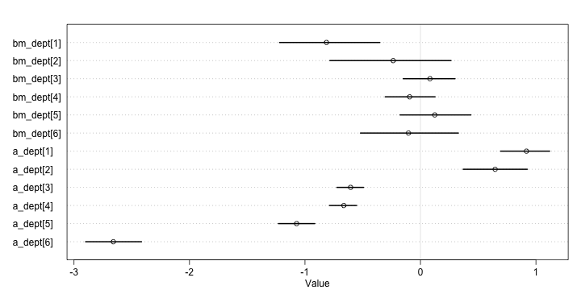

```r
plot(precis(m3, pars = c("a_dept", "bm_dept"), depth = 2) )
```

### Solution problème n°4

On peut fitter plusieurs modèles avec `brms` et les comparer ensuite en utilisant le WAIC.

```r
p1 <- c(
    prior(normal(0, 10), class = "Intercept"),
    prior(cauchy(0, 2), class = "sd")
    )

m1 <- brm(
    admit | trials(applications) ~ 1 + (1 | dept_id),
    data = d4, family = binomial,
    prior = p1,
    warmup = 1000, iter = 5000,
    control = list(adapt_delta = 0.99, max_treedepth = 12)
    )

p2 <- c(
    prior(normal(0, 10), class = "Intercept"),
    prior(normal(0, 1), class = "b"),
    prior(cauchy(0, 2), class = "sd")
    )

m2 <- brm(
    admit | trials(applications) ~ 1 + gender + (1 | dept_id),
    data = d4, family = binomial,
    prior = p2,
    warmup = 1000, iter = 5000,
    control = list(adapt_delta = 0.99, max_treedepth = 12)
    )
```

### Solution problème n°4

```r
p3 <- c(
    prior(normal(0, 10), class = "Intercept"),
    prior(normal(0, 1), class = "b"),
    prior(cauchy(0, 2), class = "sd"),
    prior(lkj(2), class = "cor")
    )

m3 <- brm(
    admit | trials(applications) ~ 1 + gender + (1 + gender | dept_id),
    data = d4, family = binomial,
    prior = p3,
    warmup = 1000, iter = 5000,
    control = list(adapt_delta = 0.99, max_treedepth = 12)
    )
```

### Solution problème n°4

```r
brms::WAIC(m1, m2, m3, compare = FALSE)
```

```
     WAIC    SE
m1 105.20 18.12
m2 108.21 16.28
m3  90.96  4.50
```

```r
library(broom)

tidy(m3, par_type = "non-varying", prob = 0.95)
```

```
       term   estimate std.error      lower     upper
1 Intercept -0.5782688 0.6742738 -1.9416181 0.7364609
2    gender -0.1707383 0.2444121 -0.6831817 0.3105980
```

### Solution problème n°4

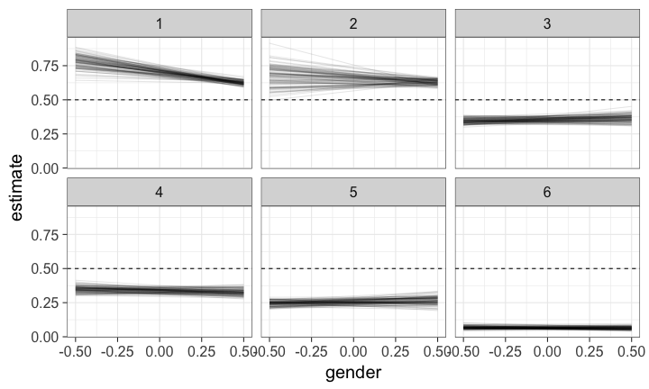

```r
library(tidybayes)
library(modelr)

d4 %>%
    group_by(dept_id, applications) %>%
    data_grid(gender = seq_range(gender, n = 1e2) ) %>%
    add_fitted_samples(m3, newdata = ., n = 100, scale = "linear") %>%
    mutate(estimate = plogis(estimate) ) %>%
    ggplot(aes(x = gender, y = estimate, group = .iteration) ) +
    geom_hline(yintercept = 0.5, lty = 2) +
    geom_line(aes(y = estimate, group = .iteration), size = 0.5, alpha = 0.1) +
    facet_wrap(~dept_id, nrow = 2) +
    theme_bw(base_size = 20)
```

### Solution problème n°5

On essaye de prédire un jugement exprimé sous forme d'entier entre 1 et 7. Autrement dit, la variable qu'on essaye de prédire est une variable catégorielle, et dont les catégories sont ordonnées de 1 à 7…

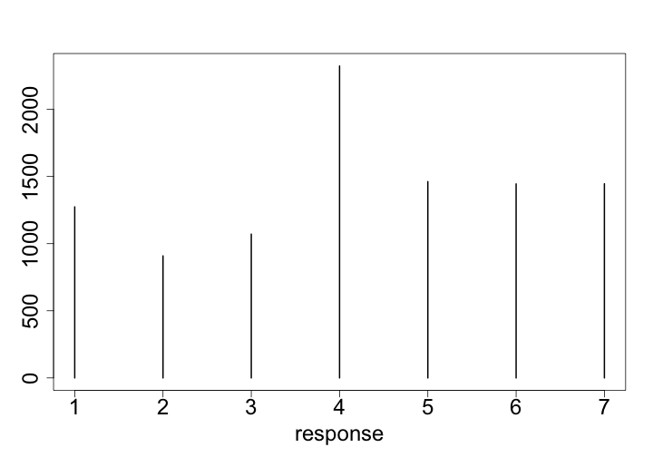

```r
d5$response %>% table %>% plot(xlab = "response", ylab = "", cex.axis = 2, cex.lab = 2)
```

### Solution problème n°5

```r
moral1 <- brm(
    response ~ 1,
    data = d5,
    family = cumulative("logit"),
    cores = parallel::detectCores(),
    control = list(adapt_delta = 0.99)
    )

moral2 <- brm(
    response ~ 1 + action + intention + contact,
    data = d5,
    family = cumulative("logit"),
    cores = parallel::detectCores(),
    control = list(adapt_delta = 0.99)
    )
```

### Solution problème n°5

Toutes les pentes sont négatives… ce qui signifie que chaque facteur réduit la réponse moyenne (i.e., le jugement de moralité). Ces pentes représentent des changements dans les log-odds cumulatifs.

```r
WAIC(moral1, moral2)
```

```
                    WAIC   SE
moral1          37854.61 57.7
moral2          37089.79 76.3
moral1 - moral2   764.81 56.0
```

```r
tidy(moral2, prob = 0.95)
```

```
             term      estimate  std.error         lower         upper
1  b_Intercept[1] -2.839851e+00 0.04648529 -2.930924e+00 -2.748893e+00
2  b_Intercept[2] -2.157050e+00 0.04225995 -2.242132e+00 -2.073793e+00
3  b_Intercept[3] -1.574161e+00 0.03881018 -1.651912e+00 -1.500618e+00
4  b_Intercept[4] -5.520921e-01 0.03625453 -6.224176e-01 -4.811386e-01
5  b_Intercept[5]  1.161913e-01 0.03613775  4.537310e-02  1.860516e-01
6  b_Intercept[6]  1.023165e+00 0.03890781  9.473870e-01  1.098028e+00
7        b_action -7.094204e-01 0.04049450 -7.905324e-01 -6.306082e-01
8     b_intention -7.208431e-01 0.03619136 -7.929248e-01 -6.484536e-01
9       b_contact -9.619983e-01 0.05029114 -1.061010e+00 -8.648803e-01
10           lp__ -1.856170e+04 2.07641545 -1.856674e+04 -1.855860e+04
```

### Solution problème n°5

On peut représenter les prédictions du modèle en utilisant la fonction `marginal_effects`.

```r
marg1 <- marginal_effects(moral2, "action", ordinal = TRUE)

p1 <-
    plot(marg1, theme = theme_bw(base_size = 20), plot = FALSE)[[1]] +
    scale_y_continuous(breaks = 1:7, labels = 1:7)

marg2 <- marginal_effects(moral2, "intention", ordinal = TRUE)

p2 <-
    plot(marg2, theme = theme_bw(base_size = 20), plot = FALSE)[[1]] +
    scale_y_continuous(breaks = 1:7, labels = 1:7)

marg3 <- marginal_effects(moral2, "contact", ordinal = TRUE)

p3 <-
    plot(marg3, theme = theme_bw(base_size = 20), plot = FALSE)[[1]] +
    scale_y_continuous(breaks = 1:7, labels = 1:7)
```

### Solution problème n°5

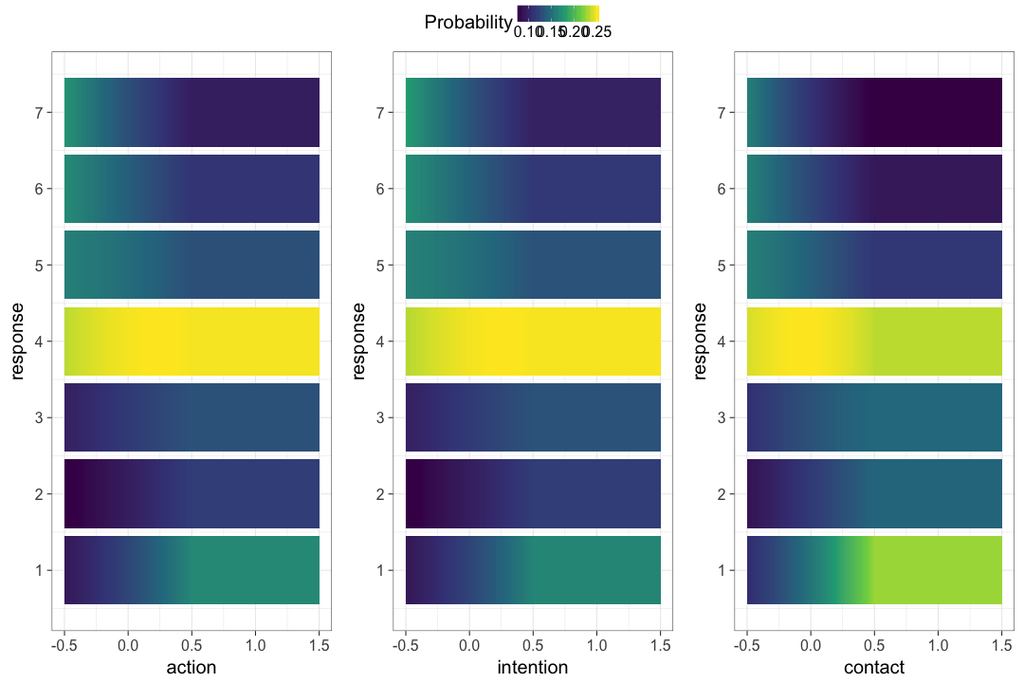

```r
ggpubr::ggarrange(p1, p2, p3, nrow = 1, ncol = 3, common.legend = TRUE)
```

### Solution problème n°5

Posterior predictive checking. Pour plus d'informations sur la régression logistique ordinale, voir [ce lien](https://stats.idre.ucla.edu/r/dae/ordinal-logistic-regression/), ce [tutorial](https://osf.io/57hdg/), ou le chapitre 11 de [McElreath (2015)](http://xcelab.net/rm/statistical-rethinking/).

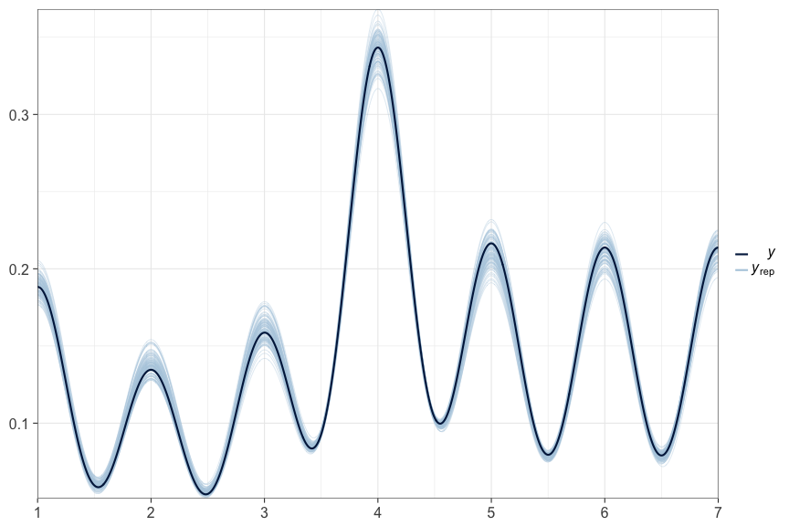

```r
pp_check(moral2, nsamples = 1e2) + theme_bw(base_size = 20)
```